# Introduction to Poisson Distribution

Lecture 4A

PUBHBIO 6250

## Count Data and Poisson Distribution

**Examples of count data**

- The number of deaths attributed to COVID-19 over a 1-year period in the US.
- The number of episodes of otitis media in the first 2 years of life.
- The number of bacterial colonies growing on an agar plate.

Count data are discrete and can take values of 0, 1, 2, and so on.

The **Poisson distribution** is the most important distribution used for count data.<sup>1</sup>

[^1]: The Poisson distribution is named after French mathematician and physicist Siméon Denis Poisson (1781–1840), who is one of the 72 names on the Eiffel Tower.

## Poisson Probability Mass Function

- Let $Y$ denote a Poisson random variable with the **probability mass function**:

$$\Pr(Y = k) = \frac{\textcolor{#BB0000}{\mu}^k}{k!}e^{-\textcolor{#BB0000}{\mu}}$$

- $k = 0, 1, 2, \dots$
- The special symbol $k!$ is called $k$ factorial, $k! = k \times (k-1) \times \cdots \times 2 \times 1$
- $e$ is approximately 2.71828
- $\mu$ = the distribution parameter
- The Poisson distribution depends on a single parameter $\mu$.
  - **Mean**: $E[Y] = \mu$
  - **Variance**: $Var(Y) = \mu$

## Poisson Mean and Variance

$$\begin{aligned}
E[Y]
&= \sum_{y = 0}^\infty y \times \textcolor{#0000FF}{Pr(Y=y)} \\
&= \sum_{y = 0}^\infty y \textcolor{#0000FF}{\frac{\mu^y}{y!} e^{-\mu}}
= 0 \frac{\mu^0}{0!} e^{-\mu} + \sum_{\textcolor{#BB0000}{y = 1}}^\infty y \frac{\mu^y}{y!} e^{-\mu} \\
&= \mu \textcolor{#0000FF}{\sum_{y = 1}^\infty \frac{\mu^{y - 1}}{(y - 1)!} e^{-\mu}}
= \mu \textcolor{#0000FF}{\sum_{y = 0}^\infty \frac{\mu^y}{y!} e^{-\mu}}
= \mu.
\end{aligned}$$

- A similar but more complicated calculation leads to $Var(Y) = \mu$.
  - $E[Y(Y-1)] = E[Y^2] - E[Y] = \mu^2$
  - $Var(Y) = E[Y^2] - E[Y]^2$
  - $Var(Y) = \mu^2 + \mu - \mu^2 = \mu$

## Poisson Distributions for Different $\mu$

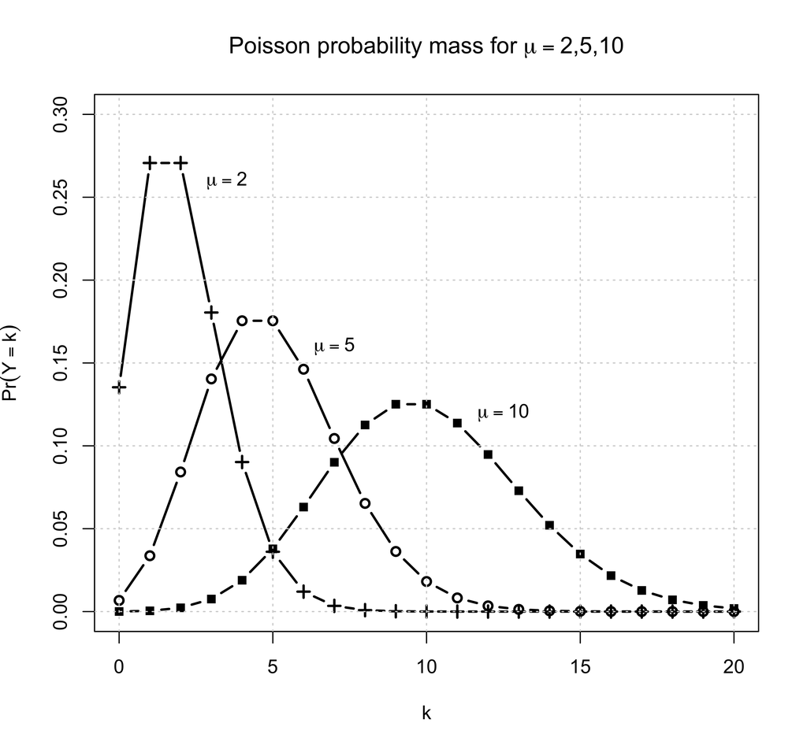

## Example

- $Y$ = the number of emergency room (ER) visits for each participant in the year following entry into a new case-management program at a local hospital
- Suppose the expected number of ER visits in a year is 3.
  - i.e., $E[Y] = 3$
- $Y \sim \text{Poisson}(\mu)$, where $\mu = 3$.
- What is the probability of exactly 2 ER visits in a year?

$$Pr(Y = k) = \frac{\mu^k}{k!}e^{-\mu}$$

- $\mu = 3$ and $k = 2$

$$Pr(Y = \textcolor{#0000FF}{2}) = \frac{\textcolor{#BB0000}{3}^{\textcolor{#0000FF}{2}}}{\textcolor{#0000FF}{2}!}e^{-\textcolor{#BB0000}{3}} \approx 0.224$$

## Poisson Approximation to the Binomial Distribution

- The $\text{Binomial}(n, p)$ distribution with a large $n$ and a small $p$ can be approximated by a $\text{Poisson}(np)$ distribution.

| Distribution | Mean | Variance |
| --- | --- | --- |
| $\text{Binomial}(n, p)$ | $np$ | $np(1-p) \approx np$ |
| $\text{Poisson}(np)$ | $np$ | $np$ |

- $Y$ = # ER visits for a participant in a year
  - Let $p$ = the probability of a participant going to the ER on each day ($p$ is small)
  - $Y \sim \text{Binomial}(365, p)$
  - The $\text{Binomial}(365, p)$ will be very close to a $\text{Poisson}(365\times p)$.

## Example: Poisson Approximation to the Binomial

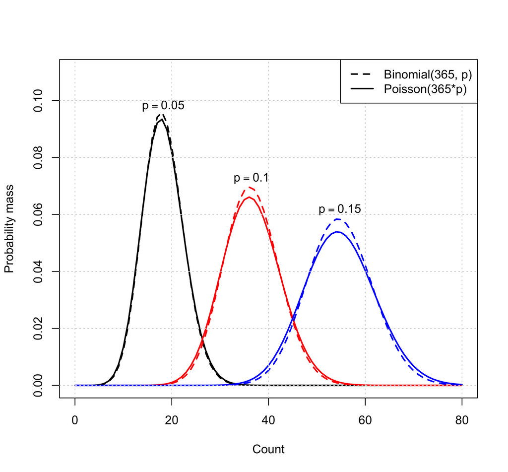

## Sums of Poisson Random Variables

- $Y_1 \sim \text{Poisson}(\mu_1)$ and $Y_2 \sim \text{Poisson}(\mu_2)$, then $Y_1 + Y_2 \sim \text{Poisson}(\mu_1 + \mu_2)$
- The sum of Poisson random variables is still a Poisson random variable, regardless of how many Poisson random variables are added.

**Example**: ER visits

- Let $p_i$ = probability of going to the ER on each day in month $i$, $i = 1, \dots, 12$
- Let $n_i$ = # of days in month $i$
- Let $Y_i$ = # of ER visits in month $i$, $Y_i \sim \text{Poisson}(n_i p_i)$
- The total number of ER visits in the year is $Y = \sum_{i=1}^{12} Y_i$.

$$Y \sim \text{Poisson}\left(\sum_{i = 1}^{12} n_i p_i\right)$$

## Summary

The Poisson distribution is the most important distribution for count data.

- It allows the count to take any integer value $\geq 0$: 0, 1, 2, 3, 4, …
- The mean and variance of the Poisson($\mu$) are both $\mu$, so the variance and mean increase together.
- The Poisson($\mu$) distribution is an approximation to the binomial($n, p$) for large $n$ and small $p$ such that $np = \mu$.
- A sum of Poisson random variables also has a Poisson distribution.